# Evaluate CNN: evaluate CNN and compute metricts after precision calibration

Thelma Panaiotis

09/01/2023

## Prepare data

Read test set predictions and scores.

```r
df <- read_csv("data/dataset/test/05.test_dataset_predictions_rf.csv", col_types = cols())  %>% select(y_true = taxon, y_pred, score = score_pred)
taxa <- sort(unique(df$y_true))
```

Plot composition of test set.

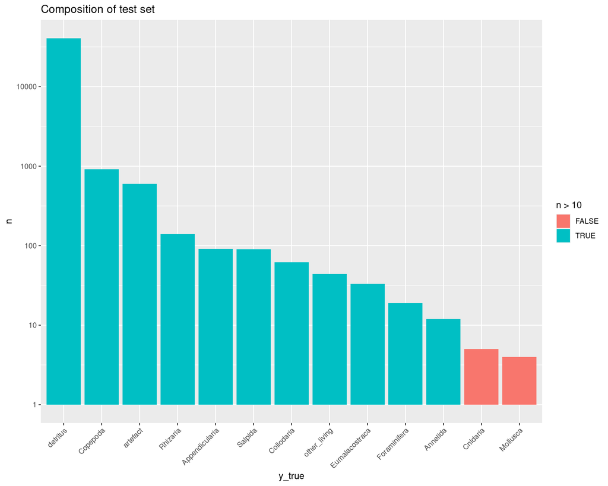

```r
counts_y_true <- df %>%
  count(y_true) %>%
  arrange(desc(n)) %>%
  mutate(y_true = fct_inorder(y_true))

counts_y_true %>%
  ggplot() +
  geom_col(aes(x = y_true, y = n, fill = n > 10)) +
  scale_y_log10() +
  theme(axis.text.x = element_text(angle = 45, vjust = 1, hjust=1)) +
  labs(title = "Composition of test set")
```

Read thresholds and join them with predictions.

```r
threshold <- read_csv("data/06.taxa_threshold.csv", col_types = cols()) %>% select(y_pred=taxon, score_threshold, plankton, usable)

test_preds <- df %>% left_join(threshold, by = "y_pred")
```

## Classification performances before thresholding

Compute global accuracy and precision and recall for each class.

```r
accuracy <- sum(test_preds$y_pred == test_preds$y_true, na.rm = TRUE) / length(test_preds$y_true)

recall <- test_preds %>%
  group_by(y_true) %>%
  summarise(recall = sum(y_true == y_pred, na.rm = TRUE) / n()) %>%
  ungroup()

precision <- test_preds %>%
  #filter(!is.na(y_new_pred)) %>%
  group_by(y_pred) %>%
  summarise(precision = sum(y_true == y_pred, na.rm = TRUE) / n()) %>%
  ungroup()

# Store precision and recall per taxon in one table
report <- full_join(precision %>% rename(class = y_pred), recall %>% rename(class = y_true), by = "class") %>%
  replace_na(list(precision = 0, recall = 0)) %>%
  left_join(counts_y_true %>% rename(class = y_true), by = "class") %>%
  left_join(threshold %>% select(class = y_pred, plankton, usable),  by = "class") %>%
  replace_na(list(n = 0)) %>%
  mutate(n_plankton = n * plankton)

# Compute average precision and recall
macro_recall <- mean(report$recall)
macro_precision <- mean(report$precision)
weighted_recall <- weighted.mean(report$recall, report$n)
weighted_precision <- weighted.mean(report$precision, report$n)
plankton_weighted_recall <- weighted.mean(report$recall, report$n_plankton)
plankton_weighted_precision <- weighted.mean(report$precision, report$n_plankton)
```

Classification metrics:

- Accuracy: 0.97
- Macro recall: 0.71
- Macro precision: 0.67
- Weighted recall: 0.97
- Weighted precision: 0.97
- Plankton weighted recall: 0.74
- Plankton weighted precision: 0.6

### Classification report

Plot a classification report to see precision and recall value for each class.

```r
report %>%
  select(-c(n_plankton, usable)) %>%
  rename(taxon = class) %>%
  arrange(taxon) %>%
  gt() %>%
  tab_header(title = "Classification report before thresholding") %>%
    cols_align(
    align = "left",
    columns = taxon
  ) %>%
  data_color(
    columns = c(precision, recall),
    colors = scales::col_numeric(
      palette = c("white", "#3fc1c9"),
      domain = NULL
    )
  )
```

Classification report before thresholding

| taxon | precision | recall | n | plankton |
| --- | --- | --- | --- | --- |
| Annelida | 0.7500000 | 0.5000000 | 12 | TRUE |
| Appendicularia | 0.3776224 | 0.5934066 | 91 | TRUE |
| Cnidaria | 0.5000000 | 0.4000000 | 5 | TRUE |
| Collodaria | 0.9482759 | 0.8870968 | 62 | TRUE |
| Copepoda | 0.6057092 | 0.7396514 | 918 | TRUE |
| Eumalacostraca | 0.5000000 | 0.8787879 | 33 | TRUE |
| Foraminifera | 0.8421053 | 0.8421053 | 19 | TRUE |
| Mollusca | 0.3750000 | 0.7500000 | 4 | TRUE |
| Rhizaria | 0.4430894 | 0.7730496 | 141 | TRUE |
| Salpida | 0.6916667 | 0.9222222 | 90 | TRUE |
| artefact | 0.8888889 | 0.6389351 | 601 | FALSE |
| detritus | 0.9862491 | 0.9810474 | 40575 | FALSE |
| other_living | 0.8235294 | 0.3181818 | 44 | TRUE |

### Recall VS precision

Let’s plot another representation.

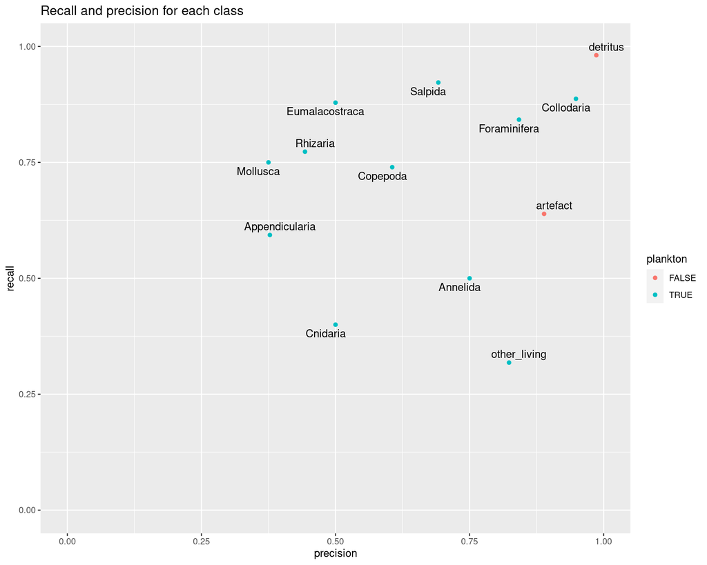

```r
report %>%
  ggplot() +
  geom_point(aes(x = precision, y = recall, color = plankton)) +
  geom_text_repel(aes(x = precision, y = recall, label = class)) +
  xlim(0, 1) + ylim(0, 1) +
  labs(title = "Recall and precision for each class")
```

### Confusion matrix

Generate and plot a confusion matrix.

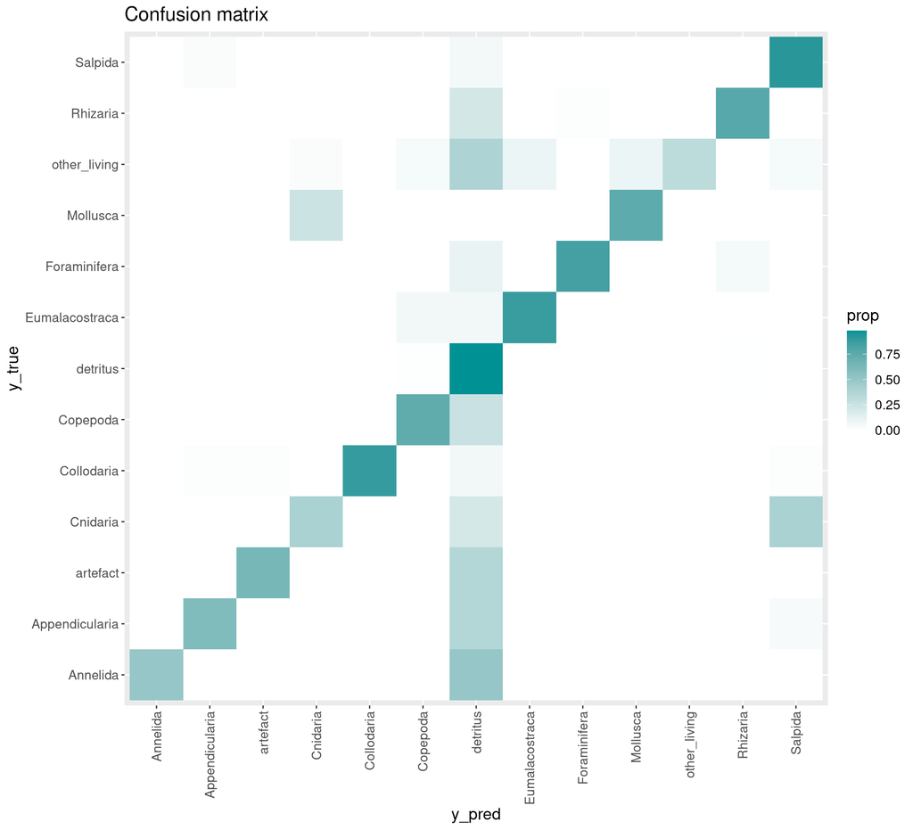

```r
CM <- ConfusionMatrix(test_preds$y_pred, test_preds$y_true) %>%
  as_tibble() %>%
  group_by(y_true) %>%
  mutate(prop = n / sum(n))

CM %>%
  ggplot() +
  geom_tile(aes(y_pred, y_true, fill= prop)) +
  scale_fill_gradient(low = "white", high = "#009194") +
  theme(axis.text.x = element_text(angle = 90, vjust = 0.5, hjust=1), text = element_text(size=14)) +
  labs(title = "Confusion matrix")
```

## Classification performances after thresholding

For each prediction with a score lower than threshold, set prediction to NA.

```r
test_preds <- test_preds %>% mutate(y_new_pred = ifelse(score > score_threshold, y_pred, NA))
```

Compute global accuracy and precision and recall for each class.

```r
accuracy <- sum(test_preds$y_new_pred == test_preds$y_true, na.rm = TRUE) / length(test_preds$y_true)

recall <- test_preds %>%
  group_by(y_true) %>%
  summarise(recall = sum(y_true == y_new_pred, na.rm = TRUE) / n()) %>%
  ungroup()

precision <- test_preds %>%
  filter(!is.na(y_new_pred)) %>%
  group_by(y_new_pred) %>%
  summarise(precision = sum(y_true == y_new_pred, na.rm = TRUE) / n()) %>%
  ungroup()

# Store precision and recall per taxon in one table
report <- full_join(precision %>% rename(class = y_new_pred), recall %>% rename(class = y_true), by = "class") %>%
  replace_na(list(precision = 0, recall = 0, n = 0)) %>%
  left_join(counts_y_true %>% rename(class = y_true), by = "class") %>%
  left_join(threshold %>% select(class = y_pred, plankton, usable),  by = "class") %>%
  replace_na(list(n = 0)) %>%
  mutate(n_plankton = n * plankton)

# Compute average precision and recall
macro_recall <- mean(report$recall)
macro_precision <- mean(report$precision)
weighted_recall <- weighted.mean(report$recall, report$n)
weighted_precision <- weighted.mean(report$precision, report$n)
plankton_weighted_recall <- weighted.mean(report$recall, report$n_plankton)
plankton_weighted_precision <- weighted.mean(report$precision, report$n_plankton)
```

Classification metrics:

- Accuracy: 0.96
- Macro recall: 0.52
- Macro precision: 0.78
- Weighted recall: 0.96
- Weighted precision: 0.98
- Plankton weighted recall: 0.52
- Plankton weighted precision: 0.77

### Classification report

Plot a classification report to see precision and recall value for each class.

```r
report %>%
  select(-c(n_plankton, usable)) %>%
  rename(taxon = class) %>%
  arrange(taxon) %>%
  gt() %>%
  tab_header(title = "Classification report after thresholding") %>%
    cols_align(
    align = "left",
    columns = taxon
  ) %>%
  data_color(
    columns = c(precision, recall),
    colors = scales::col_numeric(
      palette = c("white", "#3fc1c9"),
      domain = NULL
    )
  )
```

Classification report after thresholding

| taxon | precision | recall | n | plankton |
| --- | --- | --- | --- | --- |
| Annelida | 0.7142857 | 0.41666667 | 12 | TRUE |
| Appendicularia | 0.7586207 | 0.24175824 | 91 | TRUE |
| Cnidaria | 0.0000000 | 0.00000000 | 5 | TRUE |
| Collodaria | 0.9473684 | 0.87096774 | 62 | TRUE |
| Copepoda | 0.7518142 | 0.56427015 | 918 | TRUE |
| Eumalacostraca | 0.7741935 | 0.72727273 | 33 | TRUE |
| Foraminifera | 0.8333333 | 0.78947368 | 19 | TRUE |
| Mollusca | 1.0000000 | 0.25000000 | 4 | TRUE |
| Rhizaria | 0.8333333 | 0.07092199 | 141 | TRUE |
| Salpida | 0.7619048 | 0.88888889 | 90 | TRUE |
| artefact | 0.8909513 | 0.63893511 | 601 | FALSE |
| detritus | 0.9862488 | 0.98102280 | 40575 | FALSE |
| other_living | 0.8750000 | 0.31818182 | 44 | TRUE |

### Recall VS precision

Let’s plot another representation.

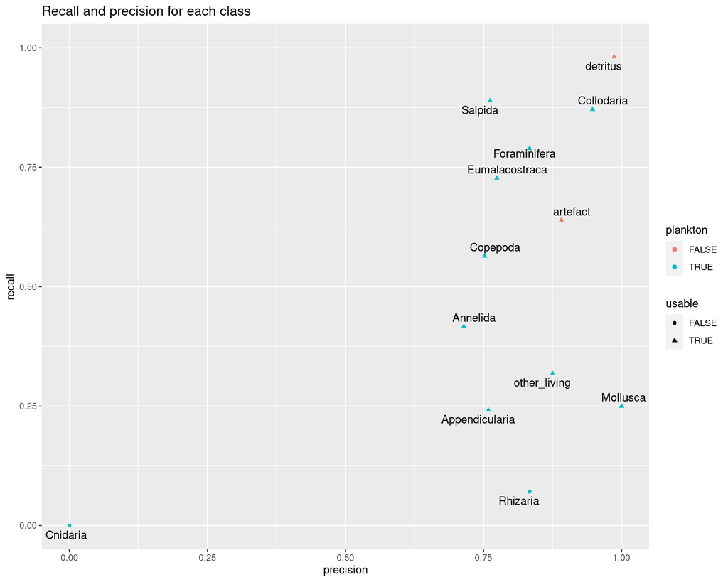

```r
report %>%
  ggplot() +
  geom_point(aes(x = precision, y = recall, color = plankton, shape = usable)) +
  geom_text_repel(aes(x = precision, y = recall, label = class)) +
  xlim(0, 1) + ylim(0, 1) +
  labs(title = "Recall and precision for each class")
```

Most classes have a decent precision, but some have a quite low recall.

### Confusion matrix

Generate and plot a confusion matrix.

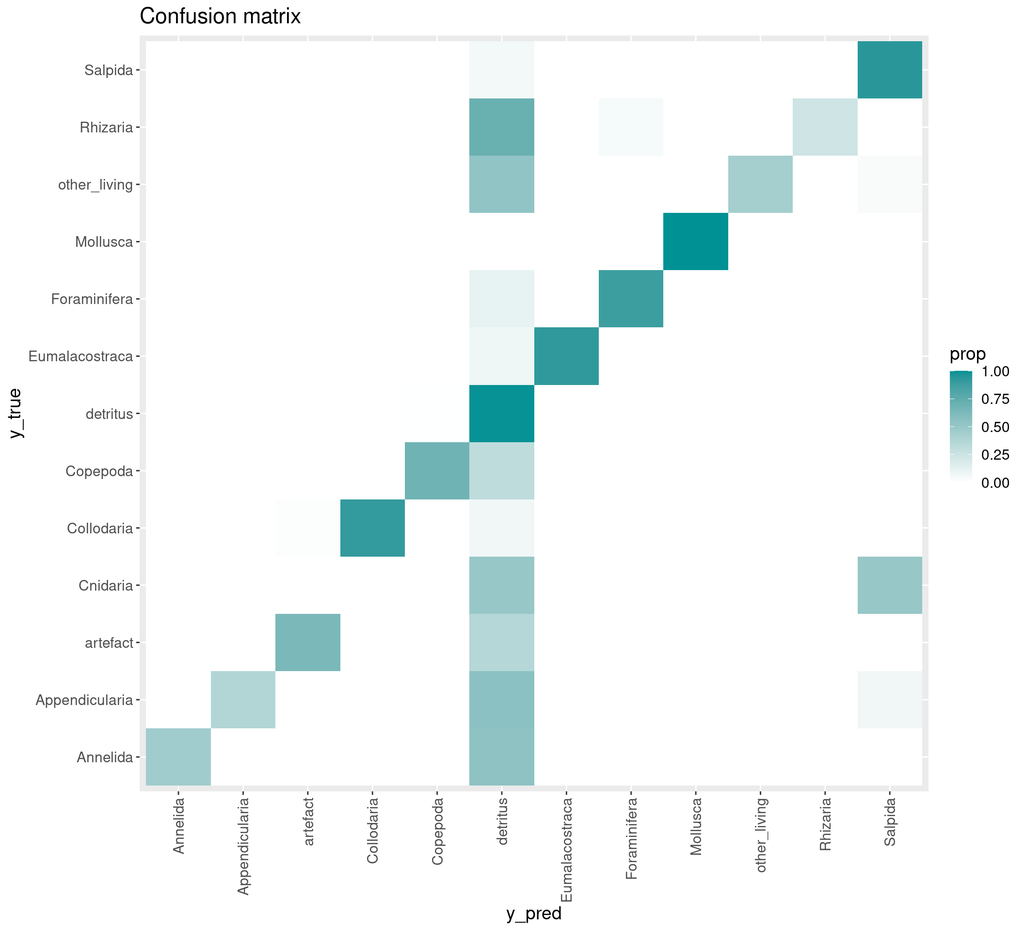

```r
CM <- ConfusionMatrix(test_preds$y_new_pred, test_preds$y_true) %>%
  as_tibble() %>%
  group_by(y_true) %>%
  mutate(prop = n / sum(n))

CM %>%
  ggplot() +
  geom_tile(aes(y_pred, y_true, fill= prop)) +
  scale_fill_gradient(low = "white", high = "#009194") +
  theme(axis.text.x = element_text(angle = 90, vjust = 0.5, hjust=1), text = element_text(size=14)) +
  labs(title = "Confusion matrix")
```

Recall of Appendicularia is very low, we will have to validate them all in Ecotaxa. Same for Rhizaria.